# Birth Death Skyline post-processing

Louis du Plessis

Last modified: 02 Oct 2022

This notebook steps through the post-processing of `bdsky_condOnRoot.xml`, the Birth Death Skyline while conditioning on the root.

# Load the trace file and check convergence

We can load the log file using the `readLog()` function.

```r
    bdsky_trace   <- beastio::readLog(params$logfile, burnin=0.1)
```

With the log file loaded as a `coda::mcmc` object we can use functions from the `coda` package to explore the trace.

```r
    summary(bdsky_trace)
    varnames(bdsky_trace)
```

We can use the `checkESS()` function to find which parameters have ESS < 200,

```r
  beastio::checkESS(bdsky_trace)
```

```
## TreeHeight.alpha
##         180.8595
```

or use the same function to plot the ESS values of all parameters.

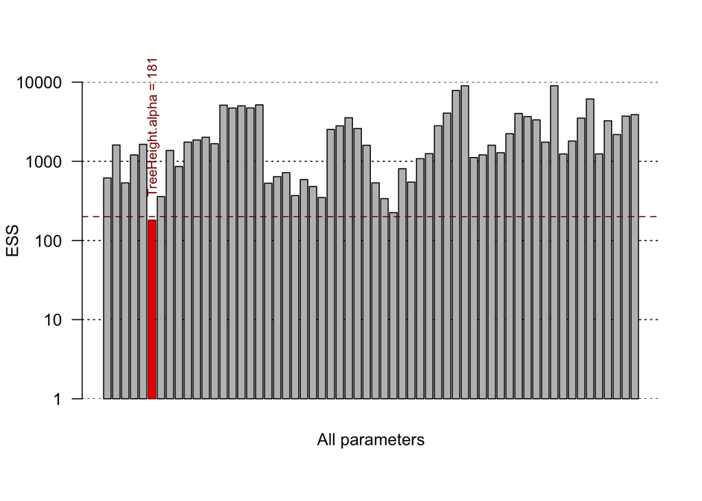

```r
  beastio::checkESS(bdsky_trace,   cutoff=200, plot=TRUE, log='y', ylim=c(1,10000), title="All parameters", plot.grid=TRUE)
```

# Alpha $R_e$

Next we can extract the $R_e$ parameter values for the Alpha alignment and their HPDs.

```r
  Re_alpha <- beastio::getLogFileSubset(bdsky_trace, "reproductiveNumber_BDSKY_SerialCondRoot.alpha")
  Re_alpha_hpd <- t(beastio::getHPDMedian(Re_alpha))
```

We can plot the raw $R_e$ HPD intervals. This is equivalent to the output in Tracer.

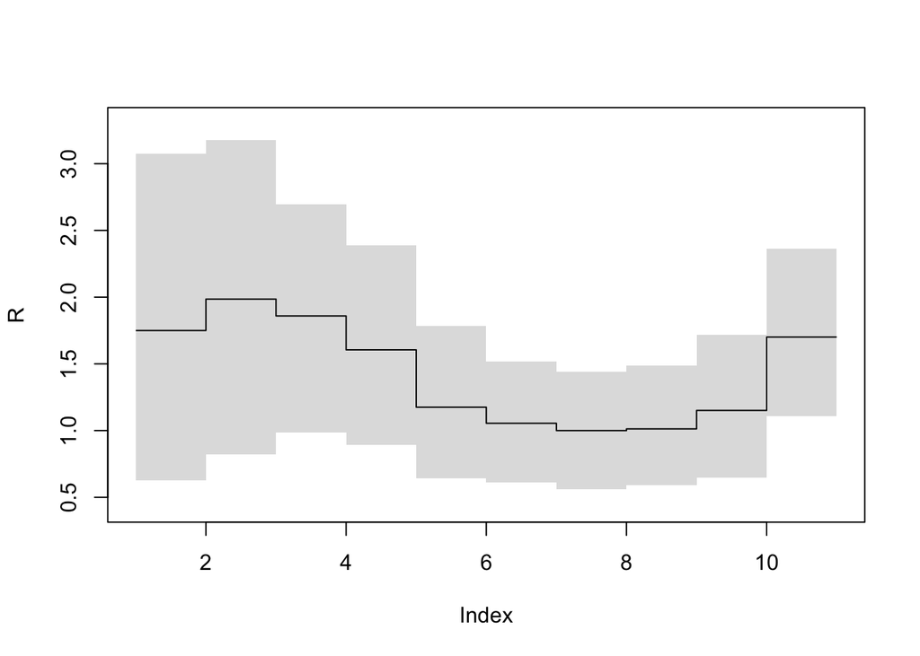

```r
    plotSkyline(1:10, Re_alpha_hpd, type='step', ylab="R")
```

In order to plot the smooth skyline we have to marginalise our $R_e$ estimates on a regular timegrid and calculate the HPD at each gridpoint. It is usually a good idea to use a grid with more cells than the dimension of $R_e$. To do this we first calculate the marginal posterior at every time of interest using the function `gridSkyline()` and then calculate the HPD for each of the finer time intervals. The times to grid the skyline on (`gridTimes_alpha`), refers to years in the past. Since we conditioned on the root we have to use the tMRCA (tree height) as an anchor point. If we didn’t condition on the root we would have to use the origin parameter.

```r
    tmrca_alpha      <- bdsky_trace[, "TreeHeight.alpha"]
    gridTimes_alpha  <- seq(0, median(tmrca_alpha), length.out=params$gridsize)

    Re_alpha_gridded <- mcmc(bdskytools::gridSkyline(Re_alpha, tmrca_alpha, gridTimes_alpha))
    Re_alpha_gridded_hpd <- t(getHPDMedian(Re_alpha_gridded))
```

Now we are ready to plot the smooth skyline.

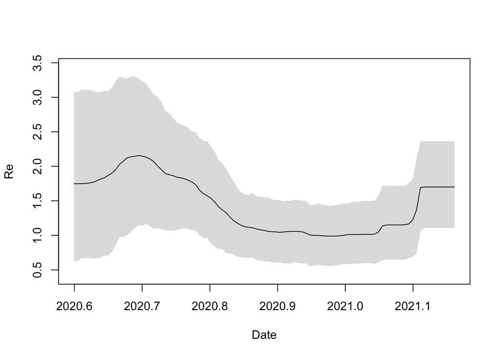

```r
    times <- lubridate::decimal_date(enddate)-gridTimes_alpha
    plotSkyline(times, Re_alpha_gridded_hpd, xlab="Date", ylab="Re")
```

We can plot the gridded $R_e$ skyline (not its HPDs) for a few of the MCMC samples to see what it really looks like as the Markov chain samples parameters. Note that the intervals overlap between different posterior samples. This is because the tMRCA is different in each of the plotted samples. As we add more samples to the plot we start to see the smooth skyline appear.

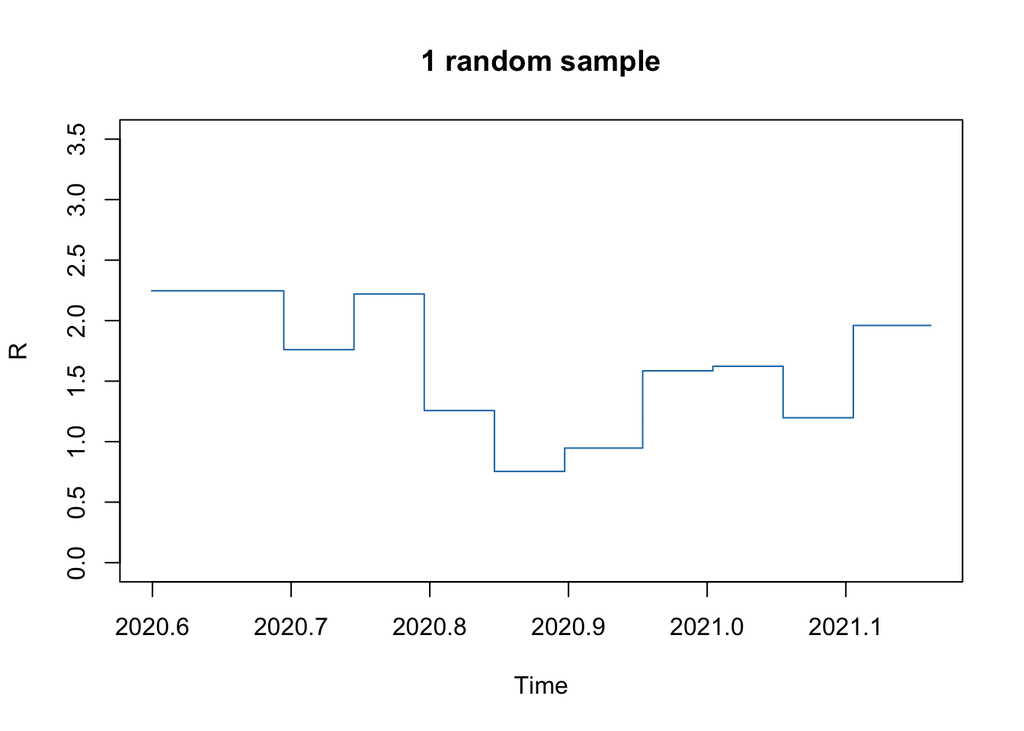

```r
    plotSkyline(times, Re_alpha_gridded, type='steplines', traces=1,
                col=cols$blue,ylims=c(0,3.5), xlab="Time", ylab="R", main="1 random sample")
```

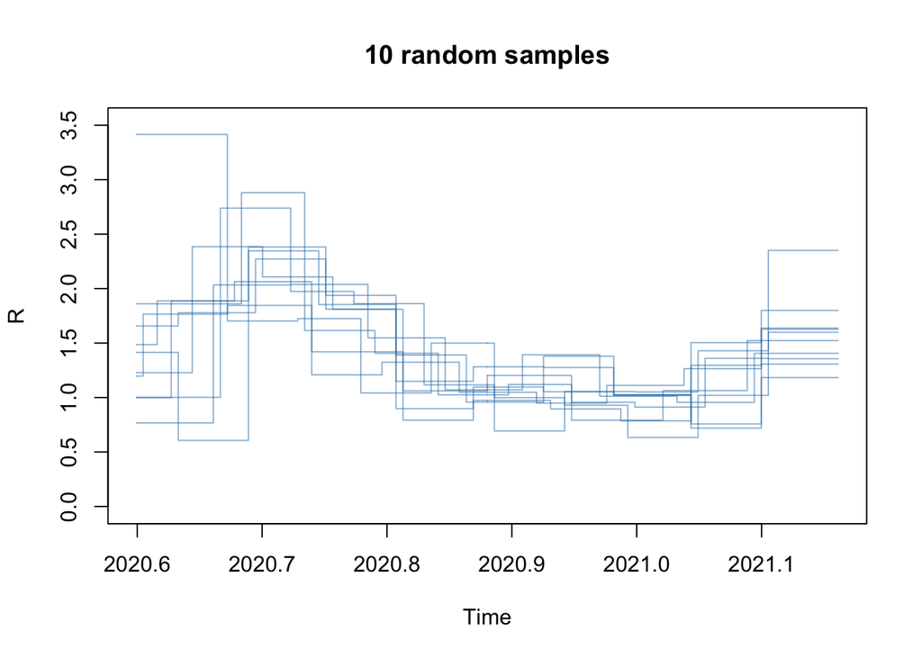

```r
    plotSkyline(times, Re_alpha_gridded, type='steplines', traces=10,
                    col=set_alpha(cols$blue,0.5),ylims=c(0,3.5), xlab="Time", ylab="R", main="10 random samples")
```

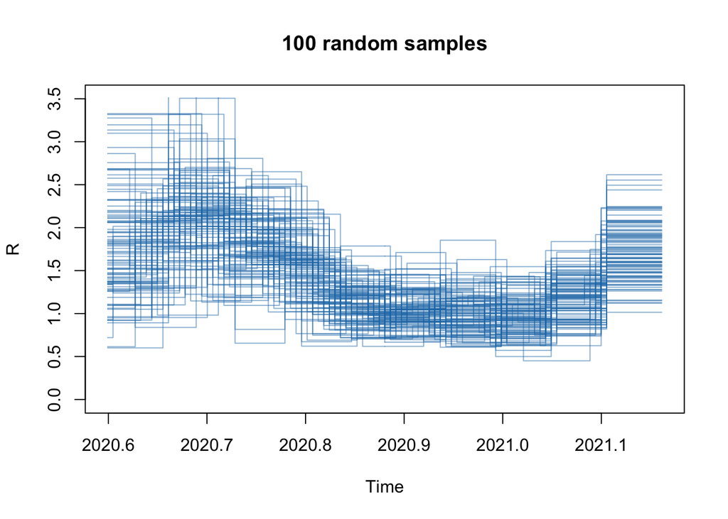

```r
    plotSkyline(times, Re_alpha_gridded, type='steplines', traces=100,
                    col=set_alpha(cols$blue,0.5),ylims=c(0,3.5), xlab="Time", ylab="R", main="100 random samples")
```

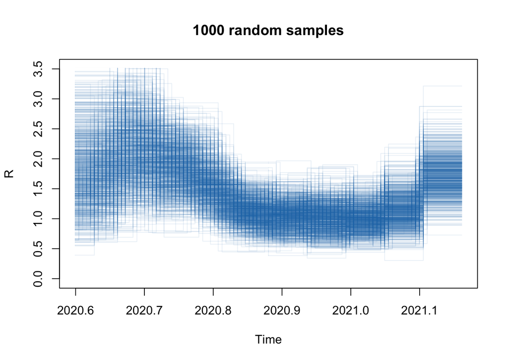

```r
    plotSkyline(times, Re_alpha_gridded, type='steplines', traces=1000,
                    col=set_alpha(cols$blue,0.1),ylims=c(0,3.5), xlab="Time", ylab="R", main="1000 random samples")
```

# Alpha sampling proportion

We can do the same for the sampling proportion estimates for the Alpha alignment.

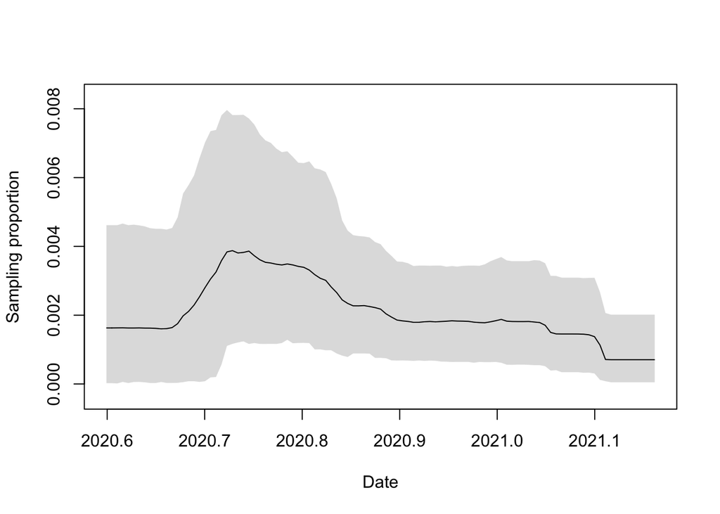

```r
    samplingProp_alpha <- beastio::getLogFileSubset(bdsky_trace, "samplingProportion_BDSKY_SerialCondRoot.alpha")
    samplingProp_alpha_gridded <- mcmc(bdskytools::gridSkyline(samplingProp_alpha, tmrca_alpha, gridTimes_alpha))
    samplingProp_alpha_gridded_hpd <- t(getHPDMedian(samplingProp_alpha_gridded))
    plotSkyline(lubridate::decimal_date(enddate)-gridTimes_alpha, samplingProp_alpha_gridded_hpd,
                xlab="Date", ylab="Sampling proportion")
```

# Background $R_e$ and sampling proportion

And we can also extract and plot the skylines for the background alignment.

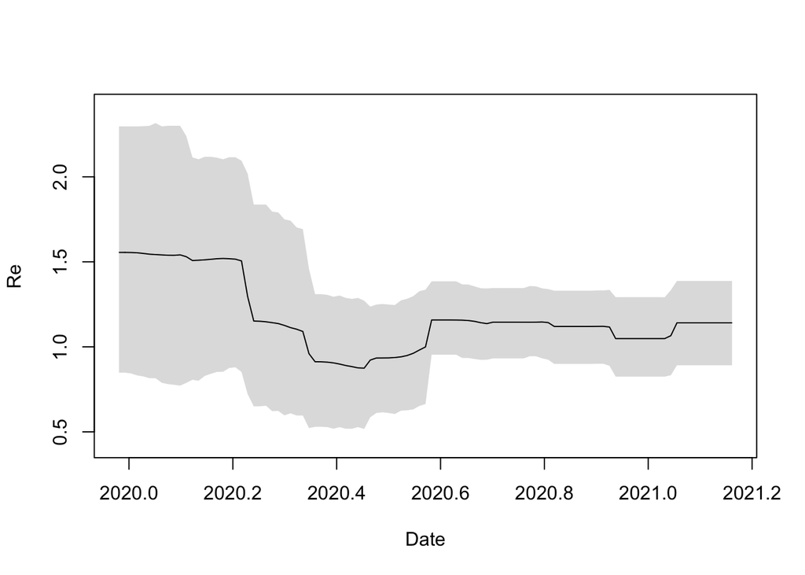

```r
    tmrca_background      <- bdsky_trace[, "TreeHeight.background"]
    Re_background         <- beastio::getLogFileSubset(bdsky_trace, "reproductiveNumber_BDSKY_SerialCondRoot.background")
    gridTimes_background  <- seq(0, median(tmrca_background), length.out=params$gridsize)

    Re_background_gridded <- mcmc(bdskytools::gridSkyline(Re_background, tmrca_background, gridTimes_background))
    Re_background_gridded_hpd <- t(getHPDMedian(Re_background_gridded))

    plotSkyline(lubridate::decimal_date(enddate)-gridTimes_background, Re_background_gridded_hpd, xlab="Date", ylab="Re")
```

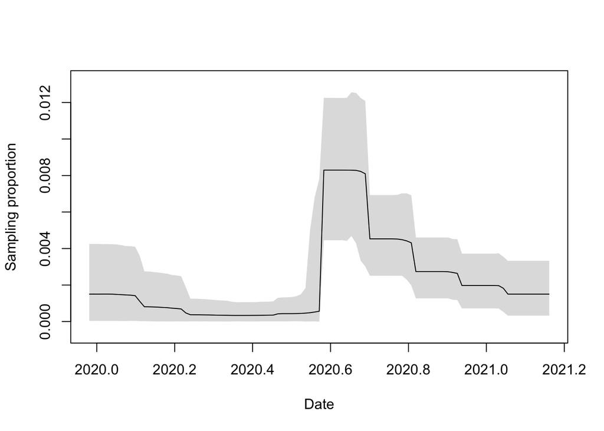

```r
    samplingProp_background <- beastio::getLogFileSubset(bdsky_trace, "samplingProportion_BDSKY_SerialCondRoot.background")

    samplingProp_background_gridded <- mcmc(bdskytools::gridSkyline(samplingProp_background, tmrca_background, gridTimes_background))
    samplingProp_background_gridded_hpd <- t(getHPDMedian(samplingProp_background_gridded))

    plotSkyline(lubridate::decimal_date(enddate)-gridTimes_background, samplingProp_background_gridded_hpd, xlab="Date", ylab="Sampling proportion")
```

# Combined

Finally, we can plot both Alpha and the background datasets on one set of axes for comparison.

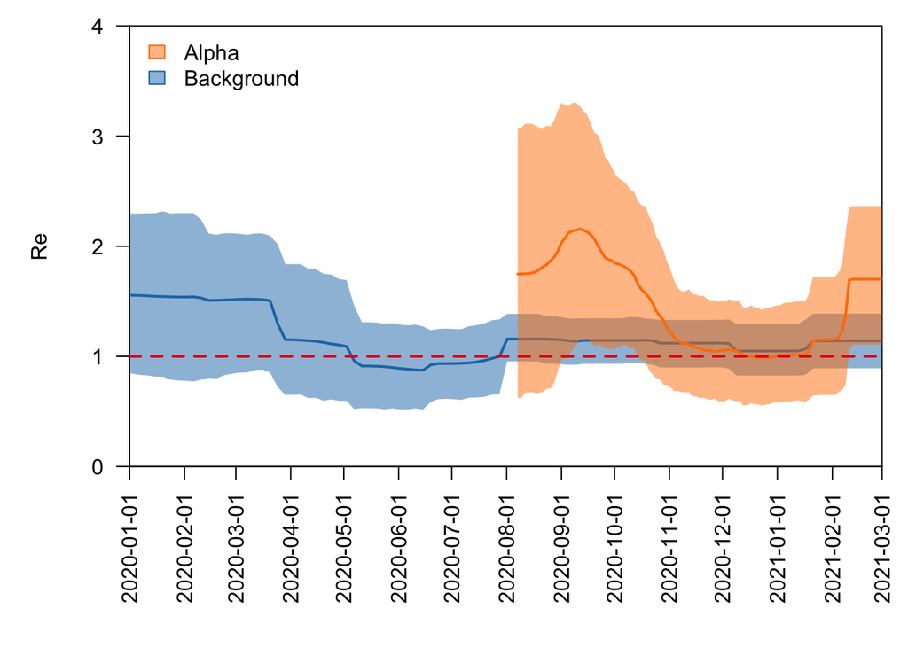

```r
    par(mar=c(7,5,1,1))
    xticks <- seq.Date(startdate, enddate, by='month')
    plot(1, type='n', xlim=lubridate::decimal_date(c(startdate, enddate)), ylim=c(0,4),
         xlab='', ylab='Re', xaxt='n', las=1, xaxs='i', yaxs='i')
    axis(1, at=lubridate::decimal_date(xticks), labels=xticks, las=2)

    plotSkyline(lubridate::decimal_date(enddate)-gridTimes_background, Re_background_gridded_hpd, lwd=2,
                xlab="", ylab="", add=TRUE, new=FALSE, axes=FALSE, fill=set_alpha(cols$blue, 0.5), col=cols$blue)

    plotSkyline(lubridate::decimal_date(enddate)-gridTimes_alpha, Re_alpha_gridded_hpd, lwd=2,
                xlab="", ylab="", add=TRUE, new=FALSE, axes=FALSE, fill=set_alpha(cols$orange, 0.5), col=cols$orange)

    abline(h = 1, lty=2, col=cols$red, lwd=2)
    legend("topleft", legend=c("Alpha", "Background"), bty='n',
           fill=set_alpha(c(cols$orange, cols$blue), 0.5), border=c(cols$orange, cols$blue))
```

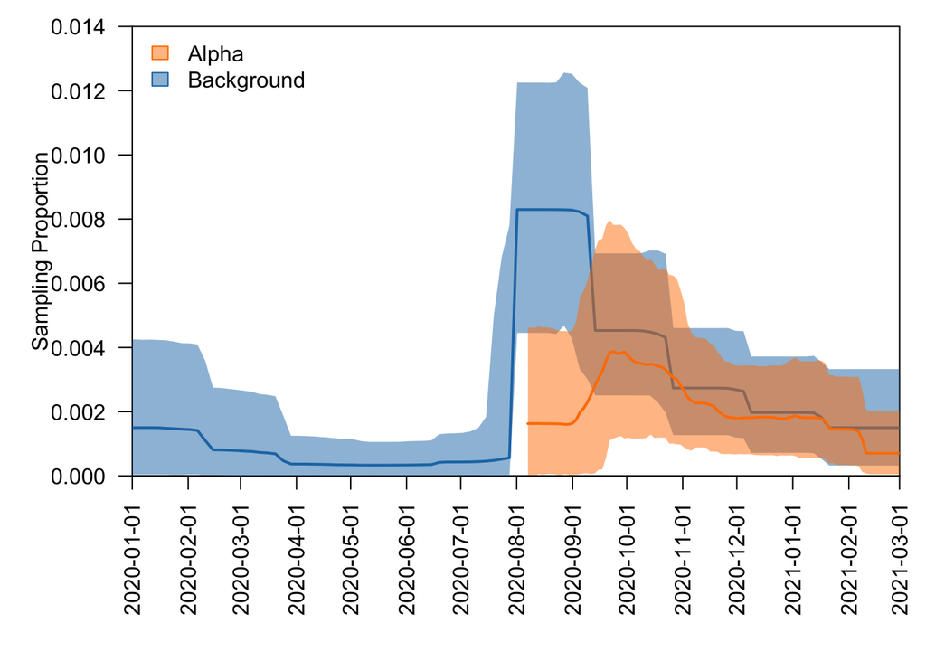

```r
    plot(1, type='n', xlim=lubridate::decimal_date(c(startdate, enddate)), ylim=c(0,0.014),
         xlab='', ylab='Sampling Proportion', xaxt='n', las=1, xaxs='i', yaxs='i')
    axis(1, at=lubridate::decimal_date(xticks), labels=xticks, las=2)

    plotSkyline(lubridate::decimal_date(enddate)-gridTimes_background, samplingProp_background_gridded_hpd, lwd=2,
                xlab="", ylab="", add=TRUE, new=FALSE, axes=FALSE, fill=set_alpha(cols$blue, 0.5), col=cols$blue)

    plotSkyline(lubridate::decimal_date(enddate)-gridTimes_alpha, samplingProp_alpha_gridded_hpd, lwd=2,
                xlab="", ylab="", add=TRUE, new=FALSE, axes=FALSE, fill=set_alpha(cols$orange, 0.5), col=cols$orange)

    legend("topleft", legend=c("Alpha", "Background"), bty='n',
           fill=set_alpha(c(cols$orange, cols$blue), 0.5), border=c(cols$orange, cols$blue))
```

# Compare to the prior

Finally, we can load the trace where we sampled from the prior and compare the skylines.

```r
    prior_trace <- beastio::readLog(params$priorfile, burnin=0.1)

    # Alpha
    Re_alpha_prior <- beastio::getLogFileSubset(prior_trace, "reproductiveNumber_BDSKY_SerialCondRoot.alpha")

    tmrca_alpha_prior      <- prior_trace[, "TreeHeight.alpha"]
    gridTimes_alpha_prior  <- seq(0, median(tmrca_alpha_prior), length.out=params$gridsize)

    Re_alpha_prior_gridded <- mcmc(bdskytools::gridSkyline(Re_alpha_prior, tmrca_alpha_prior, gridTimes_alpha_prior))
    Re_alpha_prior_gridded_hpd <- t(getHPDMedian(Re_alpha_prior_gridded))

    samplingProp_alpha_prior <- beastio::getLogFileSubset(prior_trace, "samplingProportion_BDSKY_SerialCondRoot.alpha")
    samplingProp_alpha_prior_gridded <- mcmc(bdskytools::gridSkyline(samplingProp_alpha_prior, tmrca_alpha_prior, gridTimes_alpha_prior))
    samplingProp_alpha_prior_gridded_hpd <- t(getHPDMedian(samplingProp_alpha_prior_gridded))

    # Background
    Re_background_prior <- beastio::getLogFileSubset(prior_trace, "reproductiveNumber_BDSKY_SerialCondRoot.background")

    tmrca_background_prior      <- prior_trace[, "TreeHeight.background"]
    gridTimes_background_prior  <- seq(0, median(tmrca_background_prior), length.out=params$gridsize)

    Re_background_prior_gridded <- mcmc(bdskytools::gridSkyline(Re_background_prior, tmrca_background_prior, gridTimes_background_prior))
    Re_background_prior_gridded_hpd <- t(getHPDMedian(Re_background_prior_gridded))

    samplingProp_background_prior <- beastio::getLogFileSubset(prior_trace, "samplingProportion_BDSKY_SerialCondRoot.background")
    samplingProp_background_prior_gridded <- mcmc(bdskytools::gridSkyline(samplingProp_background_prior, tmrca_background_prior, gridTimes_background_prior))
    samplingProp_background_prior_gridded_hpd <- t(getHPDMedian(samplingProp_background_prior_gridded))
```

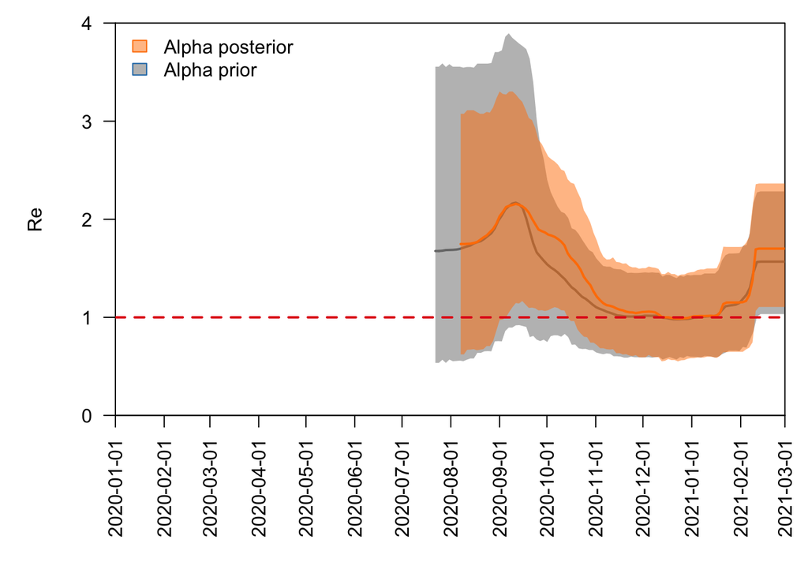

```r
    par(mar=c(7,5,1,1))
    xticks <- seq.Date(startdate, enddate, by='month')

    # Alpha Re
    plot(1, type='n', xlim=lubridate::decimal_date(c(startdate, enddate)), ylim=c(0,4),
         xlab='', ylab='Re', xaxt='n', las=1, xaxs='i', yaxs='i')
    axis(1, at=lubridate::decimal_date(xticks), labels=xticks, las=2)

    plotSkyline(lubridate::decimal_date(enddate)-gridTimes_alpha_prior, Re_alpha_prior_gridded_hpd, lwd=2,
                xlab="", ylab="", add=TRUE, new=FALSE, axes=FALSE, fill=set_alpha(cols$gray, 0.5), col=cols$gray)

    plotSkyline(lubridate::decimal_date(enddate)-gridTimes_alpha, Re_alpha_gridded_hpd, lwd=2,
                xlab="", ylab="", add=TRUE, new=FALSE, axes=FALSE, fill=set_alpha(cols$orange, 0.5), col=cols$orange)

    abline(h = 1, lty=2, col=cols$red, lwd=2)
    legend("topleft", legend=c("Alpha posterior", "Alpha prior"), bty='n',
           fill=set_alpha(c(cols$orange, cols$gray), 0.5), border=c(cols$orange, cols$blue))
```

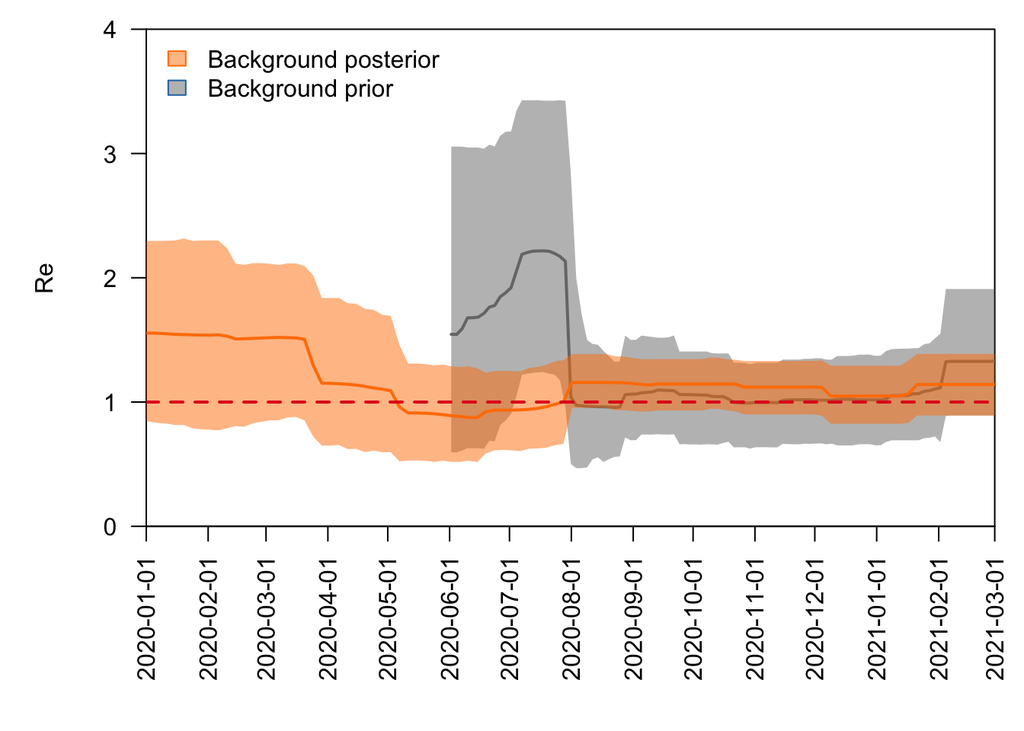

```r
    # Background Re
    plot(1, type='n', xlim=lubridate::decimal_date(c(startdate, enddate)), ylim=c(0,4),
     xlab='', ylab='Re', xaxt='n', las=1, xaxs='i', yaxs='i')
    axis(1, at=lubridate::decimal_date(xticks), labels=xticks, las=2)

    plotSkyline(lubridate::decimal_date(enddate)-gridTimes_background_prior, Re_background_prior_gridded_hpd, lwd=2,
                xlab="", ylab="", add=TRUE, new=FALSE, axes=FALSE, fill=set_alpha(cols$gray, 0.5), col=cols$gray)

    plotSkyline(lubridate::decimal_date(enddate)-gridTimes_background, Re_background_gridded_hpd, lwd=2,
                xlab="", ylab="", add=TRUE, new=FALSE, axes=FALSE, fill=set_alpha(cols$orange, 0.5), col=cols$orange)

    abline(h = 1, lty=2, col=cols$red, lwd=2)
    legend("topleft", legend=c("Background posterior", "Background prior"), bty='n',
           fill=set_alpha(c(cols$orange, cols$gray), 0.5), border=c(cols$orange, cols$blue))
```

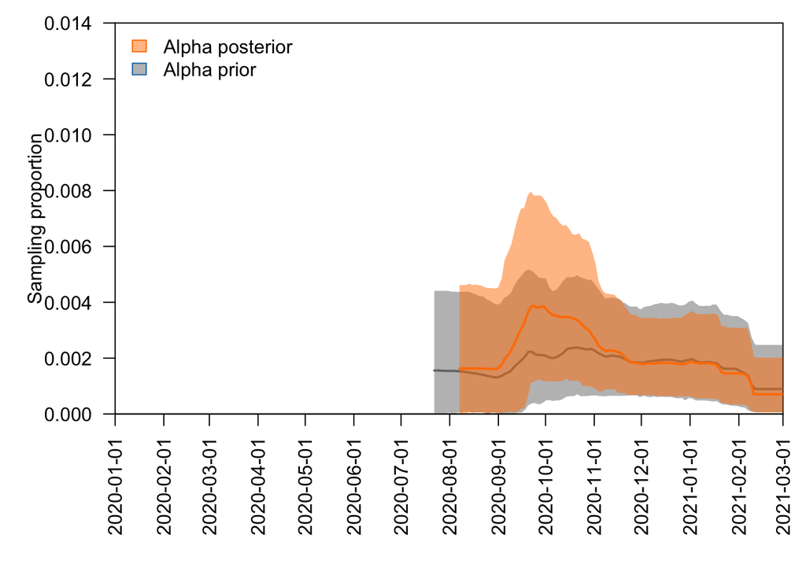

```r
    # Alpha sampling proportion
    plot(1, type='n', xlim=lubridate::decimal_date(c(startdate, enddate)), ylim=c(0,0.014),
     xlab='', ylab='Sampling proportion', xaxt='n', las=1, xaxs='i', yaxs='i')
    axis(1, at=lubridate::decimal_date(xticks), labels=xticks, las=2)

    plotSkyline(lubridate::decimal_date(enddate)-gridTimes_alpha_prior, samplingProp_alpha_prior_gridded_hpd, lwd=2,
                xlab="", ylab="", add=TRUE, new=FALSE, axes=FALSE, fill=set_alpha(cols$gray, 0.5), col=cols$gray)

    plotSkyline(lubridate::decimal_date(enddate)-gridTimes_alpha, samplingProp_alpha_gridded_hpd, lwd=2,
                xlab="", ylab="", add=TRUE, new=FALSE, axes=FALSE, fill=set_alpha(cols$orange, 0.5), col=cols$orange)

    legend("topleft", legend=c("Alpha posterior", "Alpha prior"), bty='n',
           fill=set_alpha(c(cols$orange, cols$gray), 0.5), border=c(cols$orange, cols$blue))
```

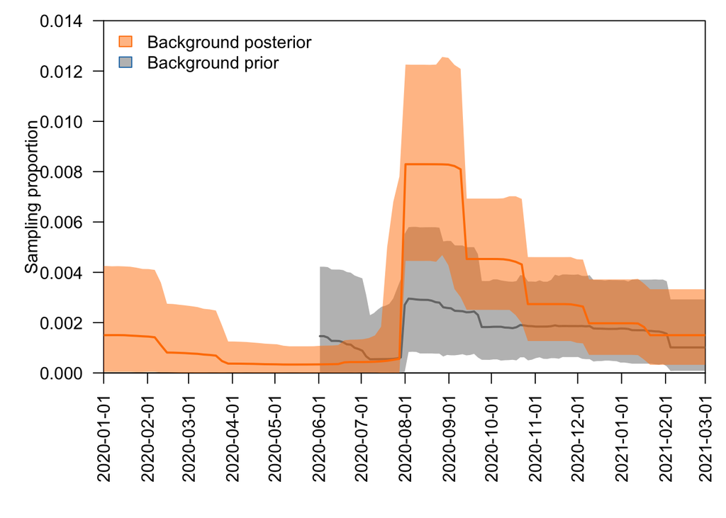

```r
    # Background sampling proportion
    plot(1, type='n', xlim=lubridate::decimal_date(c(startdate, enddate)), ylim=c(0,0.014),
     xlab='', ylab='Sampling proportion', xaxt='n', las=1, xaxs='i', yaxs='i')
    axis(1, at=lubridate::decimal_date(xticks), labels=xticks, las=2)

    plotSkyline(lubridate::decimal_date(enddate)-gridTimes_background_prior, samplingProp_background_prior_gridded_hpd, lwd=2,
                xlab="", ylab="", add=TRUE, new=FALSE, axes=FALSE, fill=set_alpha(cols$gray, 0.5), col=cols$gray)

    plotSkyline(lubridate::decimal_date(enddate)-gridTimes_background, samplingProp_background_gridded_hpd, lwd=2,
                xlab="", ylab="", add=TRUE, new=FALSE, axes=FALSE, fill=set_alpha(cols$orange, 0.5), col=cols$orange)

    legend("topleft", legend=c("Background posterior", "Background prior"), bty='n',
           fill=set_alpha(c(cols$orange, cols$gray), 0.5), border=c(cols$orange, cols$blue))
```